# 11915

axjack

2019/1/28

# データ読込

## データの出典

【ダウンロード】『ビジネス活用事例で学ぶ データサイエンス入門』事例用データとRのソースコード(URL: https://www.sbcr.jp/support/11915.html )より「section4-user_info.csv」を利用します。

## 読込処理

ローカルに落とし適当なフォルダにファイルを配置してから読み込みます。

```r
userinfo <- read.csv(file="dat/section4-user_info.csv",stringsAsFactors = F)
```

# データ構造確認

読込初期時の構造を確認しておく。

```r
dim(userinfo)
```

```
## [1] 49526     6
```

```r
str(userinfo)
```

```
## 'data.frame':    49526 obs. of  6 variables:
##  $ install_date: chr  "2013-04-15" "2013-04-15" "2013-04-15" "2013-04-15" ...
##  $ app_name    : chr  "game-01" "game-01" "game-01" "game-01" ...
##  $ user_id     : int  1 2 3 4 5 6 7 8 9 10 ...
##  $ gender      : chr  "M" "M" "F" "M" ...
##  $ generation  : int  40 10 40 10 40 40 30 20 50 20 ...
##  $ device_type : chr  "iOS" "Android" "iOS" "Android" ...
```

## install_dateの確認

要素の長さをチェックする。もし長さの種類が１種類であれば、年月日の分割は容易となるため。

```r
table( nchar( userinfo$install_date ) )
```

```
##
##    10
## 49526
```

長さの種類は１種類で、全ての要素は10桁で構成されている。つまり、全て「yyyy-mm-dd」の形式であると思われる。続いて、年月日がどのように格納されているか、`table`関数で確認する。

```r
table( substr( userinfo$install_date, 1,4 ) ) #年の部分
```

```
##
##  2013
## 49526
```

```r
table( substr( userinfo$install_date, 6,7 ) ) #月の部分
```

```
##
##    04    05    06    07    08    09
##  6320  7170  9209 11053  7884  7890
```

```r
table( substr( userinfo$install_date, 9,10 ) ) #日の部分
```

```
##
##   01   02   03   04   05   06   07   08   09   10   11   12   13   14   15
## 2000 2178 1511 1620 1344 1408 1335 1247  932 1381 1121 1135 1040 1544 1323
##   16   17   18   19   20   21   22   23   24   25   26   27   28   29   30
## 1243 2133 1432 1321 1222 2020 1625 1606 1582 1389 2731 2745 2532 2093 1864
##   31
##  869
```

年月日を分割して格納しておく。

```r
userinfo$dYear <- as.integer( substr( userinfo$install_date, 1,4 ) )
userinfo$dMonth <- as.integer( substr( userinfo$install_date, 6,7 ) )
userinfo$dDay <- as.integer( substr( userinfo$install_date, 9,10 ) )
```

ここまでのデータ構造の確認。

```r
str(userinfo)
```

```
## 'data.frame':    49526 obs. of  9 variables:
##  $ install_date: chr  "2013-04-15" "2013-04-15" "2013-04-15" "2013-04-15" ...
##  $ app_name    : chr  "game-01" "game-01" "game-01" "game-01" ...
##  $ user_id     : int  1 2 3 4 5 6 7 8 9 10 ...
##  $ gender      : chr  "M" "M" "F" "M" ...
##  $ generation  : int  40 10 40 10 40 40 30 20 50 20 ...
##  $ device_type : chr  "iOS" "Android" "iOS" "Android" ...
##  $ dYear       : int  2013 2013 2013 2013 2013 2013 2013 2013 2013 2013 ...
##  $ dMonth      : int  4 4 4 4 4 4 4 4 4 4 ...
##  $ dDay        : int  15 15 15 15 15 15 15 15 15 15 ...
```

## app_nameの確認

app_nameは何種類あるのかを確認する。

```r
table( userinfo$app_name )
```

```
##
## game-01
##   49526
```

どうやら「game-01」のみである。これはこのままにしておこう。

## user_idの確認

intなので数字が重複しているか、などを確認。

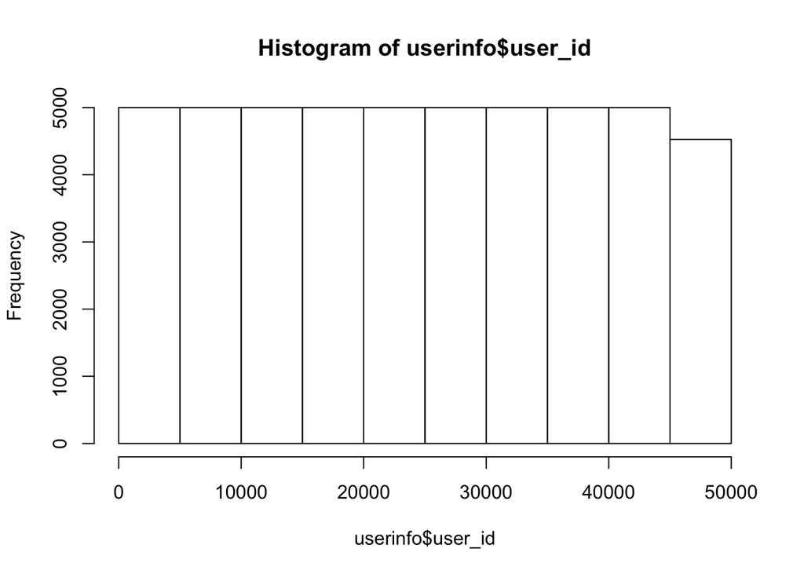

```r
hist(userinfo$user_id)
```

見事に真っ平らなヒストグラム。通番な感じですかね？もし通番なら、`1:dim(userinfo)[c(1)]`との差が0になるはずなので、一応確認。

```r
table( userinfo$user_id - 1:dim(userinfo)[c(1)] )
```

```
##
##     0
## 49526
```

全て0となった。

## generationの確認

世代はintというよりはfactorではないかと思う。まずはどんな世代がいるのか確認。

```r
table(userinfo$generation)
```

```
##
##    10    20    30    40    50
##  9756 17463 14867  4938  2502
```

10代から50代といったところでしょう。ではこれを、factorに変換する。

```r
userinfo$generation <- factor(userinfo$generation,levels=c("10","20","30","40","50"))
```

## genderとdevice_typeの確認。

```r
userinfo$gender <- factor(userinfo$gender)
userinfo$device_type <- factor(userinfo$device_type)
```

ここまでのデータ構造の確認

```r
str(userinfo)
```

```
## 'data.frame':    49526 obs. of  9 variables:
##  $ install_date: chr  "2013-04-15" "2013-04-15" "2013-04-15" "2013-04-15" ...
##  $ app_name    : chr  "game-01" "game-01" "game-01" "game-01" ...
##  $ user_id     : int  1 2 3 4 5 6 7 8 9 10 ...
##  $ gender      : Factor w/ 2 levels "F","M": 2 2 1 2 2 2 1 1 1 2 ...
##  $ generation  : Factor w/ 5 levels "10","20","30",..: 4 1 4 1 4 4 3 2 5 2 ...
##  $ device_type : Factor w/ 2 levels "Android","iOS": 2 1 2 1 2 2 1 2 2 1 ...
##  $ dYear       : int  2013 2013 2013 2013 2013 2013 2013 2013 2013 2013 ...
##  $ dMonth      : int  4 4 4 4 4 4 4 4 4 4 ...
##  $ dDay        : int  15 15 15 15 15 15 15 15 15 15 ...
```

# データ分析

```r
round( prop.table( table(userinfo[,c("gender","device_type") ]) ), digits=2)
```

```
##       device_type
## gender Android  iOS
##      F    0.25 0.25
##      M    0.25 0.25
```

```r
round( prop.table( table(userinfo[,c("gender", "generation") ]) ), digits=2)
```

```
##       generation
## gender   10   20   30   40   50
##      F 0.10 0.18 0.15 0.05 0.02
##      M 0.10 0.18 0.15 0.05 0.03
```

```r
round( prop.table( table(userinfo[,c("gender", "dMonth")] ) ), digits=2)
```

```
##       dMonth
## gender    4    5    6    7    8    9
##      F 0.06 0.07 0.09 0.11 0.08 0.08
##      M 0.06 0.07 0.09 0.11 0.08 0.08
```

```r
round( prop.table( table(userinfo[,c("generation","dMonth")] ) ), digits=2)
```

```
##           dMonth
## generation    4    5    6    7    8    9
##         10 0.03 0.03 0.04 0.04 0.03 0.03
##         20 0.05 0.05 0.07 0.08 0.06 0.06
##         30 0.04 0.04 0.06 0.07 0.05 0.05
##         40 0.01 0.01 0.02 0.02 0.02 0.02
##         50 0.01 0.01 0.01 0.01 0.01 0.01
```

```r
round( prop.table( table(userinfo[,c("gender","dMonth") ]) ), digits=2)
```

```
##       dMonth
## gender    4    5    6    7    8    9
##      F 0.06 0.07 0.09 0.11 0.08 0.08
##      M 0.06 0.07 0.09 0.11 0.08 0.08
```

```r
round( prop.table( table(userinfo[,c("device_type","dMonth") ]) ), digits=2)
```

```
##            dMonth
## device_type    4    5    6    7    8    9
##     Android 0.06 0.07 0.09 0.11 0.08 0.08
##     iOS     0.07 0.07 0.09 0.11 0.08 0.08
```